← Back to ML Fundamentals • Week 8 of 0–15

# Week 8 — ML Fundamentals

[Open in Colab](https://colab.research.google.com/github/sanketn26/learn-ml/blob/main/notebooks/week-08-saas.ipynb) [Open in VS Code](https://vscode.dev/github/sanketn26/learn-ml/blob/main/notebooks/week-08-saas.ipynb) Open in Jupyter [Download .ipynb](https://raw.githubusercontent.com/sanketn26/learn-ml/main/notebooks/week-08-saas.ipynb)

### 📝 How to Run This Notebook Locally

**1. Clone the repository:**  
`git clone https://github.com/sanketn26/learn-ml.git && cd learn-ml`

**2. Set up environment:**  
`python3 -m venv venv && source venv/bin/activate`  
`pip install jupyter notebook`

**3. Install course dependencies:**  
`pip install numpy pandas scikit-learn matplotlib scipy seaborn`  
`pip install torch`

**4. Open the notebook:**  
`jupyter notebook notebooks/week-08-saas.ipynb`

# Week 8 — Clustering: Sorting Without Labels

**Course:** Applied ML Foundations for SaaS Analytics  
**Who this is for:** Engineers who have bucketed users in SQL and wished the buckets invented themselves.

## 🎯 What you will be able to do

- Contrast supervised (“tickets with tags”) vs unsupervised (“messy inbox”)
- Run K-Means as **drop K pins, assign, scoot pins, repeat**
- Read an elbow / silhouette as “how blob-like are we,” not as a sacred K
- See why **unscaled** MRR hijacks the clusters
- Use segments as *personas for marketing*, not as a production classifier

**Think of it like… dropping pins on a map.**

You pick K (say 4). Drop 4 pins at random. Every customer walks to the nearest pin. Then each pin moves to the average location of its people. Repeat until the pins stop wandering. Those final neighborhoods are your segments.

```python
%matplotlib inline
from pathlib import Path
import sys

import numpy as np
import pandas as pd
import matplotlib.pyplot as plt

# Make the shared style kit importable whether you launch from notebooks/ or repo root
for _p in [Path.cwd(), Path.cwd() / "notebooks", Path.cwd().parent]:
    if (_p / "course_style.py").exists():
        sys.path.insert(0, str(_p))
        break

from course_style import apply_style, setup_plots, find_data_dir

apply_style()
setup_plots()
DATA = find_data_dir()
print(f"Data folder: {DATA}")
print("Laptop mode: no GPU required. Models use a sample so each week finishes in a few minutes on CPU.")

from sklearn.preprocessing import StandardScaler
from sklearn.cluster import KMeans
from sklearn.metrics import silhouette_score
```

```
Data folder: /Users/sanketnaik/workspace/learn-ml/data
Laptop mode: no GPU required. Models use a sample so each week finishes in a few minutes on CPU.
```

## Supervised vs unsupervised

```
Supervised (Weeks 6–7)          Unsupervised (this week)
X ────────► model ──► y         X ────────► model ──► group id
   you had labels                  you did not
   spam / not spam                 "these users look like each other"
```

**Engineer mental model**

Cluster *offline*. Write the persona (“whale, 3 features, high MRR”). Drive campaigns from the persona or from a simple rule. Do not call `KMeans.predict` on the request path unless you really mean it — pin locations drift every retrain and nobody will know why the user flipped from “champion” to “at risk.”

```python
from course_style import load_customer_360

df = load_customer_360(DATA)
# Keep the label on the side for storytelling — the algorithm does not get it
cols = ["mrr", "tenure_days", "log_usage", "features_adopted", "total_events"]
sample = df  # already laptop-sized from load_customer_360
X_raw = sample[cols].to_numpy()
X = StandardScaler().fit_transform(X_raw)

print("We will pretend we never saw is_churned. After clustering we will peek.")
```

```
We will pretend we never saw is_churned. After clustering we will peek.
```

## Scale first, or MRR becomes the whole personality

Without scaling, a $499 enterprise account is “farther” from a $29 starter than a power user is from a lurker. Distance thinks in raw units.

```
findfont: Failed to find font weight semibold, now using 700.
```

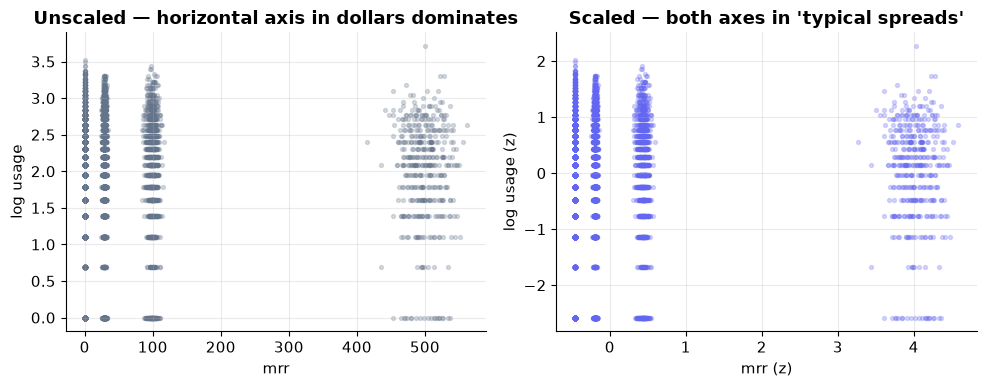

```python
# Tiny 2-D picture: MRR vs log usage, unscaled vs scaled
fig, axes = plt.subplots(1, 2, figsize=(10, 4))
axes[0].scatter(sample["mrr"], sample["log_usage"], s=8, alpha=0.25, c="#64748b")
axes[0].set_title("Unscaled — horizontal axis in dollars dominates")
axes[0].set_xlabel("mrr"); axes[0].set_ylabel("log usage")

axes[1].scatter(X[:, 0], X[:, 2], s=8, alpha=0.25, c="#6366f1")
axes[1].set_title("Scaled — both axes in 'typical spreads'")
axes[1].set_xlabel("mrr (z)"); axes[1].set_ylabel("log usage (z)")
plt.tight_layout()
plt.show()
```

## Choosing K — elbow is a suggestion, the business can overrule

**Inertia** = how far customers sit from their pin (lower is tighter).  
**Silhouette** ≈ “am I closer to my blob than to the next blob?” (higher is cleaner, max 1).

If marketing can only run 3 campaigns, you pick K=3 even if K=6 wins the silhouette contest.

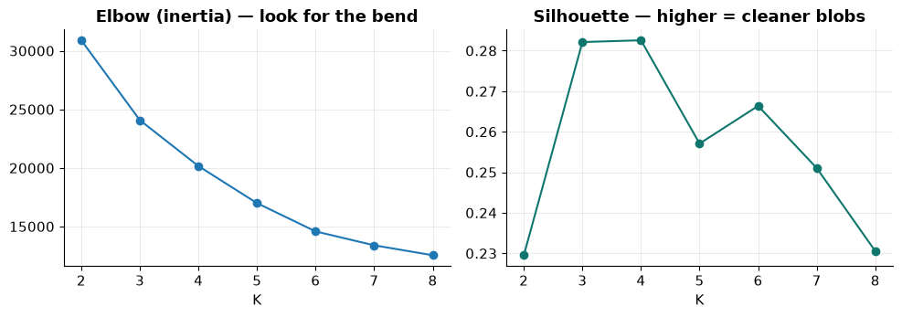

```
[(2, np.float64(0.23)), (3, np.float64(0.282)), (4, np.float64(0.283)), (5, np.float64(0.257)), (6, np.float64(0.266)), (7, np.float64(0.251)), (8, np.float64(0.231))]
```

```python
ks = range(2, 9)
inertias, sils = [], []
for k in ks:
    km = KMeans(n_clusters=k, n_init=10, random_state=42)
    labels = km.fit_predict(X)
    inertias.append(km.inertia_)
    sils.append(silhouette_score(X, labels, sample_size=3000, random_state=42))

fig, axes = plt.subplots(1, 2, figsize=(10, 3.6))
axes[0].plot(list(ks), inertias, marker="o")
axes[0].set_title("Elbow (inertia) — look for the bend")
axes[0].set_xlabel("K")
axes[1].plot(list(ks), sils, marker="o", color="#0f766e")
axes[1].set_title("Silhouette — higher = cleaner blobs")
axes[1].set_xlabel("K")
plt.tight_layout()
plt.show()
print(list(zip(ks, np.round(sils, 3))))
```

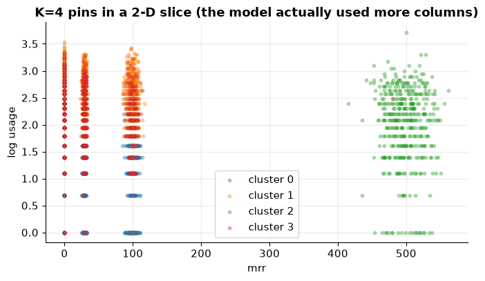

```
            n      mrr  usage  features  tenure  churn
cluster
0        2226    0.000    3.0       1.0   117.0  0.068
1        4226    0.000   10.0       3.0   103.0  0.073
2         424  497.165    7.0       2.0   142.5  0.045
3        1124    0.000    7.0       2.0   504.0  0.039

Name the rows in a PR description. If you cannot name them, K is wrong.
```

```python
K = 4
km = KMeans(n_clusters=K, n_init=10, random_state=42)
sample = sample.copy()
sample["cluster"] = km.fit_predict(X)

# 2-D view of the neighborhoods
fig, ax = plt.subplots(figsize=(7, 4.2))
for c in range(K):
    sl = sample[sample["cluster"] == c]
    ax.scatter(sl["mrr"], sl["log_usage"], s=10, alpha=0.35, label=f"cluster {c}")
ax.set_xlabel("mrr"); ax.set_ylabel("log usage")
ax.set_title("K=4 pins in a 2-D slice (the model actually used more columns)")
ax.legend()
plt.tight_layout()
plt.show()

# Persona table — including churn, which we hid from the algorithm
profile = sample.groupby("cluster").agg(
    n=("user_id", "count"),
    mrr=("mrr", "median"),
    usage=("total_usage", "median"),
    features=("features_adopted", "median"),
    tenure=("tenure_days", "median"),
    churn=("is_churned", "mean"),
).round(3)
print(profile.to_string())
print("\nName the rows in a PR description. If you cannot name them, K is wrong.")
```

K-Means always fills K buckets, even if the data is a smear. **DBSCAN** says: “a cluster is a dense pocket; loners are noise.” You pick a radius (`eps`) and a minimum crowd (`min_samples`), not K.

On 5-D scaled data, `eps=0.5` is a guess. If everything is noise, raise `eps`. If everything is one blob, lower it.

**Ship / don’t ship**

Clustering is a workshop tool: personas, onboarding tracks, “who should see this email.” It is not a replacement for the Week 6 churn model. Do not put cluster ids into a legal document — they will move next Tuesday.

## ✍️ Exercises

**1. Unscaled K-Means.** Cluster on raw `mrr` + `total_usage` (no scaler). Profile the clusters. Did MRR eat the result?

**2. Name the personas.** From the K=4 table above, write a one-line name and one marketing action per cluster. If two rows get the same name, merge them.

**3. Peek, don’t train.** Churn *rate* by cluster is a story. Training a classifier *on cluster id* is usually weaker than training on the original features — the id is a lossy compression.

## 🤔 Reflection

1. Why is “the algorithm found our enterprise plan” a failure, not a success? (You already had that column.)
2. Silhouette says K=2, marketing wants K=5. Who wins?
3. What breaks if you re-fit K-Means nightly and email users based on last night’s id?

## 🔗 Next week

Too many columns. PCA: JPEG for tabular data — keep the big shapes, drop the noise.

← Previous Week Back to ML Fundamentals Next Week →